© Guven

# Hyperparameter Optimization

## Introduction

```
"Premature optimization is the root of all evil", Donald Knuth
```

Do you know that the computing engine(s) behind most AI systems are in fact optimization algorithms? The advancements in the efficiency of computing such as multicore processors and GPGPU parallel processing helped a growth in the theory, methods, and algorithms of numerical optimization. The process of optimization is the process of obtaining the 'best', when 'good' or 'bad' can be measured. Optimization theory is the branch of mathematics encompassing the quantitative study of optima and methods for finding them. Optimization practice, is the collection of techniques, methods, procedures, and algorithms that can be used to find those optima.

Optimization problems occur in almost all disciplines like engineering, physics, mathematics, economics, administration, commerce, social sciences, and politics. Among optimization problems are finding the optimal trajectory, identifying the seismic properties, designing a portfolio of investments, controlling a chemical process or a mechanical device, allocating resources, computing the optimal shape of an automobile or aircraft component, and determining the parameters or hyperparameters of a learning model.

## Optimization

Greedy algorithms is a natural method for optimization problems. Greedy methods are easy to implement and quite efficient in most of the cases. If the underlying problem is **convex** then the greedy algorithm will result in a **global optimization**. Otherwise, the greedy approach may result in a **local optimum**. Thus, a greedy algorithm is an algorithmic paradigm based on the greedy-choice heuristic that follows local optimal choice at each step, hoping to find a globally optimal solution. An example we have seen is the least square optimization in linear regression problems where the cost function is the sum of residuals.

Note that the information about the convex/non-convex property of the problem at hand may not be available at the beginning or during. Thus, a drawback of greedy methods is that the approach might be greedy without the knowledge if the global optimum can ever be reached. As an example in data analytics or application of neural networks, the greedy heuristic optimizers are the main optimization tools, such as the gradient descent optimizer.

Though greedy algorithms do not guarantee a global optimum, they are always of polynomial complexity (or faster) algorithms.

Some examples of non-convex problems that an optimum solution is not guaranteed by greedy heuristics (but still applied) are Boolean Satisfiability (SAT), Traveling Salesman, Graph Coloring, Vertex Cover, Hamiltonian Path, Clique, 0-1 Knapsack, and Job Scheduling.

## Convex Optimization Problems

An **optimization problem** has the form,

$\boxed{\begin{aligned} \qquad & \underset{x}{\text{minimize}} & & f_o(x) \\ & \text{subject to} & & f_i(x) \le b_i, i=1,\dots,m \end{aligned}}$

The vector $x=(x_1,\dots,x_n)$ is the optimization variable of the problem, the function $f_o : \mathbb{R}^n \rightarrow \mathbb{R}$ is the **objective** function, the functions $f_i : \mathbb{R}^n \rightarrow \mathbb{R}, i=1,\dots,m$ are the **constraint** functions, and the constants $b_1,\dots,b_m$ are the bounds for the constraints.

A convex optimization problem is one in which the **objective** $f_o$ and **constraint** $f_i$ functions are convex, or in other words, they satisfy the inequality,

$\qquad f_i(\alpha x + \beta y) \le \alpha f_i(x) + \beta f_i(y)$

for all $x, y \in \mathbb{R}^n$ and all $\alpha, \beta \in \mathbb{R}$ with $\alpha + \beta = 1, \alpha \ge 0, \beta \ge 0$.

### Components of Greedy Optimization

1. A candidate solution $x_o \in \mathbb{R}^n$
2. A feasibility function to determine whether a candidate can be used to contribute to the solution, i.e. $f_i(x_o) \le b_i$ hold for $\forall i$
3. A selection function to pick the best candidate to be evaluated as a solution
4. An objective function $f_o$ to assign a value to a solution $x_o$, i.e. evaluate $x_o$
5. A solution function to indicate whether a complete solution has been reached

### Convex Sets

A set $C \subseteq \mathbb{R}^n$ is convex if $\alpha x_1 + (1-\alpha)x_2 \in C$, for $x_1, x_2 \in C$ and any $\alpha \in [0,1]$.

### Convex Functions

Geometrically, a function $f$ is convex if the line segment drawn from any point ($x_1$, $f(x_1)$) to another point ($x_2$, $f(x_2)$) **always** lies on, above (minimization), or below (maximization) the graph of $f(x)$, as demonstrated in the cell below. This line segment is called the chord from $x_1$ to $x_2$.

Algebraically, a function $f$ is convex if $f(t x_1 + (1-t)x_2) \le t f(x_1) + (1-t) f(x_2), \forall x_1, x_2 \in \textbf{dom} f$, and $\forall t \in \mathbb{R}$ where $0 \le t \le 1$

A function is concave if $-f$ is convex, i.e. if the chord from $x_1$ to $x_2$ lies on or below the graph of $f(x)$. A linear function is both convex and concave.

### Evaluative Feedback from Reinforcement Learning

**Evaluating** actions $\longleftrightarrow$ **instructing** by giving correct actions

Pure evaluative feedback depends completely on the action taken  
Pure instructive feedback depends not at all on the action taken

Supervised learning is instructive; optimization is evaluative

Associative: Inputs mapped to Outputs; learn the best output for each input Non-associative: *learn* (find) one best Output

```python
%matplotlib inline
import matplotlib.pyplot as plt
plt.rcParams['figure.dpi'] = 72
from IPython.display import display
import numpy as np
import pandas as pd
from random import random
import sys
```

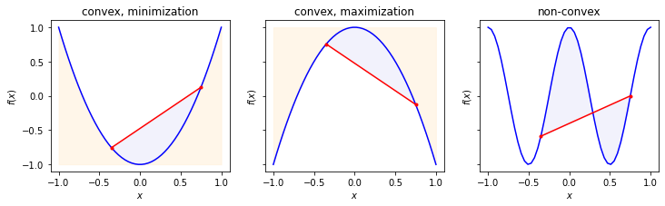

```python
# plot
def plotx(_ax, _x, _x1, _x2, _func, _title, region=0):
    _y, _y1, _y2 = _func(_x), _func(_x1), _func(_x2)
    _ax.plot(_x,_y, c='b')
    _ax.plot([_x1,_x2], [_y1,_y2], c='r', marker = '.')
    _ax.fill_between(np.linspace(_x1,_x2), _func(np.linspace(_x1,_x2)), np.linspace(_y1,_y2), color='lavender', alpha=0.5)
    if region == 0:  # minimization
        _ax.fill_between(_x, [min(_y)]*len(_x), _y, color='papayawhip', alpha=0.5)
    elif region == 1:  # maximization
        _ax.fill_between(_x, _y, [max(_y)]*len(_x), color='papayawhip', alpha=0.5)
    _ax.set(xlabel='$x$', ylabel='$f(x)$', title=_title)

def show_convex():
    _, ax_ = plt.subplots(1, 3, figsize=(12, 3), sharey='all')
    # x and f(x)
    x, x1, x2 = np.linspace(-1,1), -0.35, 0.75

    plotx(ax_[0], x, x1, x2, lambda _: 2*_**2-1, 'convex, minimization', region=0)
    plotx(ax_[1], x, x1, x2, lambda _: -2*(_**2)+1, 'convex, maximization', region=1)
    plotx(ax_[2], x, x1, x2, lambda _: np.cos(2*np.pi*_), 'non-convex', region=2)
    plt.show()

show_convex()
```

## Gradient Descent Algorithm

Given the minimization problem, the minimum of a function $f(x)$, $x \in \mathbb{R}^n$, and $f : \mathbb{R}^n \rightarrow \mathbb{R}$. Denote the gradient of $f$ by $g_k = g(x_k) = \nabla f(x_k)$.

The general idea behind most *greedy* optimization methods is to compute a *step* along a given search *direction,* $d_k$, such as,

$\quad x_{k+1} = x_k + \alpha_k d_k, \quad k= 0, 1, \dots$

where the step length, $\alpha_k$, is chosen (the steepest descent) so that

$\quad \alpha_k = \underset{\alpha}{\text{arg min}} \phi_k(\alpha) = \underset{\alpha}{\text{arg min}} f(x_k + \alpha d_k)$

Here $\text{arg min}$ refers to the argument of the minimum for the given function. For the gradient descent method, the search direction is given by $d_k = -\nabla f(x_k)$. Then the algorithm:

Given an initial $x_o$, and $d_o=-g_o$, and a convergence tolerance $\textbf{tol}$,

```
for k in range(maxiter):
    a[k] = argmin(a) phi[k]
    x[k+1] = x[k] - a[k]*g[k]
    compute g[k+1]
    if norm(g[k+1]) <= tol:
        stop  # converged
```

Gradient descent requires the step length $\alpha_k \in \mathbb{R}^+$ and the gradient computation. One of the disadvantages of gradient descent is oscillation where a convergence is never achieved, due to almost flat $f$ surface causing the derivative being close to zero.

Note that Steepest Descent is a special case of gradient descent where the step length ($\in \mathbb{R}^+$) is chosen to minimize the objective function value. Gradient descent refers to any of a class of algorithms that calculate the gradient of the objective function, then move *downhill* in the indicated direction, so that the step length can be fixed, or estimated (e.g. line search).

## Particle Swarm Optimization

Particle swarm optimization (PSO) is a continuous optimization method inspired by naturally occurring animal swarms, such as bird flocks or insect swarms. The method searches for a *best* solution (measured according to each solution's fitness) from among candidate-solution particles moving around in the feasible solution space like a swarm. Similar to the individual members of a swarm, particles tend to follow each other, set by the PSO iteration model. A solution in our problem is the set of RPM parameters which generates the best detection performance (fitness) according to the cost function.

PSO starts with a group of $S$ many particles (solutions) at random locations in the feasible parameter space. Each movement of a particle represents a generation of a genetic algorithm, which searches the solution space for better cost values or better optima. At every iteration, particles move to new positions according to their speed and previous positions. In addition, each particle receives a new heading vector according to the discovered better solutions by other particles. These better solutions are

- $\text{lbest}_i$ local best – the best cost value (optimum) that particle $i$ has seen so far
- $\text{gbest}$ global best – the best cost value (optimum) that any particle has seen so far, i.e., $\min(\text{lbest}_i)$

These two values are used to update the particle speed (scaled by a random factor). The particles' speed and direction are initialized randomly (or by a grid). During every iteration, the current solutions for each particle are calculated and then $\text{lbest}_i$ and $\text{gbest}$ are updated. The algorithm stops after a specified maximum number of iterations or once a minimum error criterion is reached (such as no improvement in $\text{gbest}$ in the last $K$ iterations).

For a one-dimensional solution (i.e., a single cost parameter), the following models update of particle velocities $V$ and positions $X$ at each iteration for particle $i=1,\dots ,S$:

$\qquad V^{(k+1)} = V^{(k)}+c_1 \mathbf{rand}(\text{lbest}_i–X^{(k)})+c_2 \mathbf{rand}(\text{gbest}–X^{(k)})$  
$\qquad X^{(k+1)} = X^{(k)}+V^{(k)}$

as an example, where $c_1=.5$, $c_2=.5$, $S=10$ number of particles (i.e. swarm size), $\mathbf{rand}$ is a random number generator function. Pilot studies can be conducted to decide on $c_1$, $c_2$ and $S$ which are deemed as sensitive optimization parameters.

If the optimization problem is multidimensional of size $N$, then vectors $V$, $X$, $\mathbf{rand}$ are defined multidimensional as well as $\text{lbest}_i$ and $\text{gbest}$ (i.e., all these vectors are $\in \mathbb{R}^N$).

The PSO algorithm has the advantage of not requiring the computation of derivatives. However, it is a greedy approach that is not guaranteed to converge to a global minimum. PSO is best suited for problems where the solution space is non-convex. PSO works best with numerically independent variables (statistically independent features) as opposed the generic genetic algorithms. A good uniform random number generator is crucial to make sure the particles wander around enough to discover better solutions. The advantages of PSO over genetic algorithms other optimization methods such as simulated annealing include:

- Continuous optimization
- Very simple to implement, parallelizable, and fast to run
- Flexible, can be controlled with the number of particles $S$ and $c_1$, $c_2$ coefficients
- Derivative-free (unlike gradient descent)

PSO vectors, $V$, $X$, $\text{lbest}_i$, $\text{gbest}$ $\in \mathbb{R}^N$, where $1 \le i \le S$

Cost function, $C(X): \mathbb{R}^N \to \mathbb{R}$

Example, $C(X) = 5 \cdot (1-P_d) + P_f$

where $P_d = \frac{\text{TP}}{\text{TP}+\text{FN}}$ and $P_f = \frac{\text{FP}}{\text{TN}+\text{FP}}$ and the cost function is subjectively determined by the learning model designer.

Constraints, $b_{i,mn} \le x_i \le b_{i,mx}$ for $1 \le i \le S$, each $(b_{i,mn},b_{i,mx})$ provided by the problem.

## Bayesian Optimization

Optimizing $f: \mathbf{X} \to \mathbb{R}$ on some domain $X \subseteq \mathbf{X}$ and finding a global minimum $x^*$ which is defined as $x^* = \underset{x \in X}{\text{arg min}} f(x)$. We seek a local optimum in the neighborhood of a given initial point $x_0$.

A common approach to optimization problems is to make some assumptions about $f$. If the objective function $f$ is convex and the domain $X$ is also convex, then the problem becomes easier to solve as in Support Vector Machine optimization and such.

If an exact functional form for $f$ is not available or $f$ behaves as a "black-box" then we can use gradient descent as in neural network optimization, or particle swarm optimization as in the previous section. Another approach is Bayesian optimization which maintains a probabilistic belief about $f$ and designs an acquisition function to determine where to evaluate the function next. Bayesian optimization is particularly useful when $f$ is an expensive black-box function.

Bayesian optimization reasons about $f$ by choosing an appropriate Gaussian process prior (compute mean $\mu$ and covariance $K$ functions for $f$),

$p(f) = \mathcal{GP}(f;\mu,K)$

Given observations $D = (X;f)$, condition the distribution on $D$ as

$p(f \mid D) = \mathcal{GP}(f;\mu_{f \mid D}, K_{f \mid D})$

The meta approach in Bayesian optimization is to design an acquisition function $a(x)$ which is typically an inexpensive function that can be evaluated at a given point that is commensurate with how desirable evaluating $f$ at $x$ is expected. Then optimize the acquisition function to select the location of the next observation. Resulting replacement of original optimization problem with another optimization problem, but on a cheaper function $a(x)$.

### Acquisition Functions

Many acquisition functions can be interpreted in the framework of Bayesian decision theory as evaluating an expected loss associated with evaluating $f$ at a point $x$. Then select the point with the lowest expected loss. Some examples,

- Probability of improvement, $f^\prime = \min \mathbf{f}$, $u(x)=\begin{cases} 0 & f(x) > f^\prime \\ 1 & f(x) <leq f^\prime \end{cases}$, and $a_{\text{PI}} = \mathbb{E}[u(x) \mid x,D]$
- Expected improvement, $u(x)=\max(0,f^\prime - f(x))$, and $a_{\text{EI}} = \mathbb{E}[u(x) \mid x,D]$
- Entropy search, $x^* = \underset{x \in \mathbf{X}} {\text{arg min}} f(x)$, and $u(x)=H[x^* \mid D]-H[x^* \mid D,x,f(x)]$
- Upper confidence bound, $a_{UCB}(x;\beta)=\mu(x)-\beta \sigma(x)$, tradeoff $\beta > 0$, and $\sigma(x)=\sqrt{K(x,x)}$  
  (default for `bayesian-optimization`)

## Example Hyperparameter Optimization

Let's see how the disinformation dataset created in an earlier course be used to demonstrate hyperparameter optimization. We will use regular grid search, PSO, and Bayesian optimization to determine an optimum model. A cross validation scheme assures the hyperparameter search without bias. In addition, we will use a random forest classifier with the hyperparameters `n_estimators`, `max_depth`, and `max_features` to find out the best learned model.

Install [Particle Swarm Optimization](https://pyswarms.readthedocs.io/en/latest/index.html) and [Bayesian Optimization](https://github.com/bayesian-optimization/BayesianOptimization) libraries.

- `conda install pyswarms`↩
- `conda install bayesian-optimization`↩

```python
# read disinformation dataset, Tf-Idf preprocessed
df = pd.read_csv('../../../EP_datasets/disinformation.csv')
display(df.head())

dataX = df.loc[:, df.columns != 'class'].values
datay = df.loc[:, df.columns == 'class'].values.ravel()
```

|  | f01 | f02 | f03 | f04 | f05 | f06 | f07 | f08 | f09 | f10 | ... | f92 | f93 | f94 | f95 | f96 | f97 | f98 | f99 | f100 | class |
| --- | --- | --- | --- | --- | --- | --- | --- | --- | --- | --- | --- | --- | --- | --- | --- | --- | --- | --- | --- | --- | --- |
| 0 | 0.0 | 0.0 | 0.0 | 0.0 | 0.0 | 0.0 | 0.0 | 0.0 | 0.0 | 0.0 | ... | 0.00000 | 0.0 | 0.0 | 0.0 | 0.0 | 0.0 | 0.0 | 0.0 | 0.0 | 0 |
| 1 | 0.0 | 0.0 | 0.0 | 0.0 | 0.0 | 0.0 | 0.0 | 0.0 | 0.0 | 0.0 | ... | 0.00000 | 0.0 | 0.0 | 0.0 | 0.0 | 0.0 | 0.0 | 0.0 | 0.0 | 1 |
| 2 | 0.0 | 0.0 | 0.0 | 0.0 | 0.0 | 0.0 | 0.0 | 0.0 | 0.0 | 0.0 | ... | 0.78201 | 0.0 | 0.0 | 0.0 | 0.0 | 0.0 | 0.0 | 0.0 | 0.0 | 1 |
| 3 | 0.0 | 0.0 | 0.0 | 0.0 | 0.0 | 0.0 | 0.0 | 0.0 | 0.0 | 0.0 | ... | 0.00000 | 0.0 | 0.0 | 0.0 | 0.0 | 0.0 | 0.0 | 0.0 | 0.0 | 0 |
| 4 | 0.0 | 0.0 | 0.0 | 0.0 | 0.0 | 0.0 | 0.0 | 0.0 | 0.0 | 0.0 | ... | 0.00000 | 0.0 | 0.0 | 0.0 | 0.0 | 0.0 | 0.0 | 0.0 | 0.0 | 0 |

5 rows × 101 columns

```python
from sklearn.metrics import accuracy_score, confusion_matrix
from sklearn.model_selection import StratifiedKFold

from sklearn.ensemble import RandomForestClassifier

def run_classifier(_clf, blog=False):
    global dataX, datay, pso_log
    _X, _y = dataX, datay
    tpr, fpr, acc = [], [], []
    kf = StratifiedKFold(n_splits=10, shuffle=True, random_state=0)
    for tr_i, ts_i in kf.split(_X, _y):
        _clf.fit(_X[tr_i], _y[tr_i])
        y_pred = _clf.predict(_X[ts_i])
        acc += [accuracy_score(_y[ts_i], y_pred)]
        tn, fp, fn, tp = confusion_matrix(_y[ts_i], y_pred, labels=[1,0]).ravel()
        tpr += [tp/(tp+fn)]  # Probability
        fpr += [fp/(fp+tn)]  # False alarm
    tpr, fpr = np.mean(tpr), np.mean(fpr)
    if blog:
        pso_log += [(tpr, fpr)]  # to log progress or OP
    return np.mean(acc), np.std(acc), tpr, fpr
```

```python
# Hyperparameters, alphabetical
N_ESTIM= (20,100)
MAX_DEP= (2,7)
MAX_FEA= (3,20)
```

```python
%%time

# Grid Search

def run_params_randomforest():
    Tpr, Fpr, Acc, Std = [], [], [], []
    # grid search
    for ne in np.linspace(N_ESTIM[0],N_ESTIM[1], num=3, dtype=int):
        for md in np.linspace(MAX_DEP[0],MAX_DEP[1], num=3, dtype=int):
            for mf in np.linspace(MAX_FEA[0],MAX_FEA[1], num=3, dtype=int):
                acc, std, tpr, fpr = run_classifier(  # classifier
                    RandomForestClassifier(n_estimators=ne, max_depth=md, max_features=mf, n_jobs=-1))
                Acc += [acc]; Std += [std]; Tpr += [tpr]; Fpr += [fpr]
                # debug
                # print(f'RF acc={acc:.2f} {chr(177)}{std:.3f}')
                sys.stderr.write(f'\rRF acc={acc:.2f} {chr(177)}{std:.3f}   params=({ne:3d},{md:3d},{mf:3d})')
                sys.stderr.flush()
    return Tpr, Fpr, Acc, Std

Tpr1, Fpr1, Acc1, Std1 = run_params_randomforest()
```

```
RF acc=0.80 ±0.009   params=(100,  7, 20)
```

```
CPU times: total: 5min 40s
Wall time: 51.8 s
```

```python
# PSO

def avg(_x):
    return (_x[0]+_x[1])/2.

def costf_pso(_X):  # PSO minimizes
    """
    _X is the list of particles called by the pyswarms library
    (S, M) = _X.shape
    S number of particles
    M number of dimensions, i.e. number of independent variables, hyperparameters
    """
    def costf(_pd, _pf):
        return 5*(1.-_pd)+_pf

    S = _X.shape[0]  # number of particles
    # each particle cost function is evaluated
    costs = np.ones((S,), dtype=float)

    for i in range(S):
        hp = np.array(_X[i], int)  # hyperparameters are integers
        clf = RandomForestClassifier(n_estimators=hp[0], max_depth=hp[1], max_features=hp[2], n_jobs=-1)
        acc, std, tpr, fpr = run_classifier(clf, blog=True)
        costs[i] = costf(tpr, fpr)

    return costs
```

```python
from pyswarms.single import GeneralOptimizerPSO
from pyswarms.backend.topology import Star, Ring, VonNeumann, Random, Pyramid

N_PARTICLES= 7  # number of particles

N_HYPERPARAMS= 3  # number of hyperparameters

# Swarm parameters
# c1:cognitive parameter, c2:social parameter, w:inertia parameter, k:num neighbors, p:L1 or L2
PYSWARM_OPTS= {'c1': 0.5, 'c2': 0.5, 'w': 0.7, 'k': 3, 'p': 2}

# Constraints are alphabetical
Constraints = (np.array([N_ESTIM[0], MAX_DEP[0], MAX_FEA[0]], dtype=float),
               np.array([N_ESTIM[1], MAX_DEP[1], MAX_FEA[1]], dtype=float))

init_pos = np.array([avg(N_ESTIM), avg(MAX_DEP), avg(MAX_FEA)])  # middles of the contraint ranges
Init_pos= np.array([init_pos+1-2*random() for _ in range(N_PARTICLES)])

PSO_ITERS_N= 10  # number of iterations

optimizer = GeneralOptimizerPSO(  # GeneralOptimizerPSO
    n_particles= N_PARTICLES,
    dimensions= N_HYPERPARAMS,
    options= PYSWARM_OPTS,
    topology= Star(),
    bounds= Constraints,
    init_pos= Init_pos,
    )
```

```python
%%time

pso_log = []  # collect Pd Pf

# run the optimizer
pso_cost, pso_pos = optimizer.optimize(costf_pso, iters=PSO_ITERS_N)
```

```
2023-09-16 22:12:34,548 - pyswarms.single.general_optimizer - INFO - Optimize for 10 iters with {'c1': 0.5, 'c2': 0.5, 'w': 0.7, 'k': 3, 'p': 2}
2023-09-16 22:15:01,515 - pyswarms.single.general_optimizer - INFO - Optimization finished | best cost: 0.5186425248702031, best pos: [61.62594645  6.70462419 12.92271566]
```

```
CPU times: total: 18min 50s
Wall time: 2min 26s
```

```python
# PSO best solution
print(f'cost= {pso_cost:.3f}')
pso_op_params = [int(pso_pos[_]) for _ in range(N_HYPERPARAMS)]
print(f'OP params= {pso_op_params}')

# best OP
_, _, pso_tpr, pso_fpr = run_classifier(
    RandomForestClassifier(n_estimators=pso_op_params[0],
                           max_depth=pso_op_params[1], max_features=pso_op_params[2], n_jobs=-1))

Fpr2, Tpr2 = [_[1] for _ in pso_log], [_[0] for _ in pso_log]
Std2 = 0.02*np.ones((len(Tpr2),), dtype=float)
```

```
cost= 0.519
OP params= [61, 6, 12]
```

```python
# Bayesian Optimization

from bayes_opt import BayesianOptimization

# constraints
pbounds = {'ne':N_ESTIM, 'md':MAX_DEP, 'mf':MAX_FEA}

def costf_bop(ne, md, mf):  # Bayesian Op maximizes
    cost = costf_pso(np.array([ne, md, mf]).reshape(-1,3))
    return -cost[0]

boptim = BayesianOptimization(
    f= costf_bop,
    pbounds= pbounds,
    random_state=0,
)
```

```python
%%time

pso_log = []  # collect Pd Pf

# run the optimizer
boptim.maximize(init_points=3, n_iter=PSO_ITERS_N)
```

```
|   iter    |  target   |    md     |    mf     |    ne     |
-------------------------------------------------------------
| 1         | -0.5294   | 4.744     | 15.16     | 68.22     |
| 2         | -1.268    | 4.724     | 10.2      | 71.67     |
| 3         | -0.5367   | 4.188     | 18.16     | 97.09     |
| 4         | -0.5299   | 5.346     | 15.08     | 87.71     |
| 5         | -0.6413   | 3.151     | 19.28     | 50.66     |
| 6         | -0.7434   | 4.706     | 12.4      | 78.61     |
| 7         | -3.557    | 2.977     | 7.682     | 26.91     |
| 8         | -4.427    | 2.0       | 3.0       | 100.0     |
| 9         | -1.604    | 2.0       | 20.0      | 80.24     |
| 10        | -0.5125   | 7.0       | 10.39     | 57.01     |
| 11        | -0.5229   | 6.914     | 11.91     | 57.38     |
| 12        | -4.402    | 2.0       | 3.0       | 48.5      |
| 13        | -1.434    | 2.045     | 19.9      | 61.03     |
=============================================================
CPU times: total: 3min 7s
Wall time: 26.9 s
```

```python
# Bayesian Op best solution
print(f"cost= {boptim.max['target']:.3f}")
bop_op_params = [int(boptim.max['params']['ne']), int(boptim.max['params']['md']), int(boptim.max['params']['mf'])]
print(f"OP params= {bop_op_params}")

# best OP
_, _, bop_tpr, bop_fpr = run_classifier(
    RandomForestClassifier(n_estimators=bop_op_params[0],
                           max_depth=bop_op_params[1], max_features=bop_op_params[2], n_jobs=-1))

Fpr3, Tpr3 = [_[1] for _ in pso_log], [_[0] for _ in pso_log]
Std3 = 0.02*np.ones((len(Tpr3),), dtype=float)
```

```
cost= -0.512
OP params= [57, 7, 10]
```

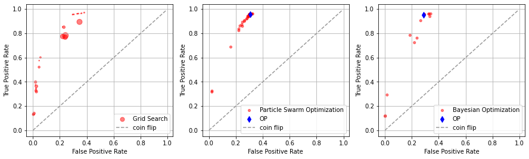

```python
# Size of the marker shows the error variance for grid search
COEF = 200
Std10 = (COEF*np.array(Std1))**2
Std20 = (COEF*np.array(Std2))**2
Std30 = (COEF*np.array(Std3))**2

def plotr(_ax, _fpr, _tpr, _std0, _label, op=None):
    _ax.scatter(_fpr, _tpr, s=_std0, marker='o', c='r', label=_label, alpha=0.5)
    if op is not None:
        _ax.scatter(op[0], op[1], s=50, marker='d', c='b', label='OP')
    _ax.plot(np.arange(0.001,1,0.01), np.arange(0.001,1,0.01), linestyle='--', color=(0.6, 0.6, 0.6), label='coin flip')
    _ax.set(xlabel='False Positive Rate', ylabel='True Positive Rate')
    _ax.grid()
    _ax.legend()

_, ax = plt.subplots(1, 3, figsize=(15,4), dpi=72)
ax = ax.flatten()

plotr(ax[0], Fpr1, Tpr1, Std10, 'Grid Search')
plotr(ax[1], Fpr2, Tpr2, Std20, 'Particle Swarm Optimization', op=(pso_fpr,pso_tpr))
plotr(ax[2], Fpr3, Tpr3, Std30, 'Bayesian Optimization', op=(bop_fpr,bop_tpr))

plt.show()
```

## Early Stopping in Optimizations

Optimal stopping or early stopping in math is the problem of choosing a time to take a particular action, to maximize or minimize a function, such as in reinforcement learning. An example of an optimal stopping problem is the secretary problem where hiring the best secretary among $n$ rankable candidates and requires a sequential hire decision accept or reject right after the interview. During the interviews the rank information builds up. The odds algorithm implies that the optimal win probability is always at least $\frac{1}{e}$, thus an optimal stopping rule prescribes always rejecting the first $\sim \frac{n}{e}$ applicants that are interviewed and then stopping at the first applicant who is better than every applicant interviewed so far (or continuing to the last applicant if this never occurs). Sometimes this strategy is called the $\frac{1}{e}$ stopping rule.

In machine learning, the early stopping is a form of regularization used to diminish overfitting when training a learner with an iterative method, such as gradient descent. In previous modules we have seen that training accuracy goes up and validation accuracy settles at some point. An ideal stopping could be as soon as the validation performance starts saturating, or starts decreasing. Keeping iterative training checkpoints one can optimize a particular model among the checkpoints as soon as the early stopping kicks in.

Some frameworks use an `EarlyStopping` callback to monitor a metric (such as the validation) and stop the training when no improvement is observed.

## References

1. Boyd, Stephen, Stephen P. Boyd, and Lieven Vandenberghe. Convex optimization. Cambridge University Press, 2004.
2. Kennedy, James, and Russell Eberhart. "Particle swarm optimization." Proceedings of ICNN'95-International Conference on Neural Networks. Vol. 4. IEEE, 1995.
3. Snoek, Jasper, Hugo Larochelle, and Ryan P. Adams. "Practical bayesian optimization of machine learning algorithms." Advances in neural information processing systems 25 (2012).
4. Freeman, P. R. "The secretary problem and its extensions: A review." International Statistical Review/Revue Internationale de Statistique (1983): 189-206.

## Exercises

**Exercise 1.** Comment about the OPs close to (0.30, 0.95) coordinate in Particle Swarm Optimization ROC.

**Exercise 2.** Change the acquisition function in Bayesian optimization.

**Exercise 3.** Implement an early stopping method in the `fit` method of a neural network implementation.

```python
%%html
<style>
    table {margin-left: 0 !important;}
</style>
<!-- Display markdown tables left oriented in this notebook. -->
```